# exp preference

Allen Yeh

```r
library(tidyverse)
library(gmodels)
library(rstatix)
```

```r
library(ggplot2)
library(ez)
library(ARTool)
library(emmeans)
```

### functions

```r
percent <- function(num, digits = 2, ...) {
  percentage <-formatC(num * 100, format = "f", digits = digits, ...)

  # appending "%" symbol at the end of
  # calculate percentage value
  paste0(percentage, "%")
}

INT <- function(x){
    qnorm((rank(x) - 0.5)/length(x))
}
```

### Import data

#### Read the csv file and claim the data type

```r
key_code = c("A", "S", "D", "F", "J", "K", "L", "Semicolon")

two_level_code = c("full", "light")
three_level_code = c("full", "medium", "light")
four_level_code = c("full", "mediumHigh", "mediumLow", "light")

level2_data <- read_csv("./../results/rating/2_levels.csv", col_types = cols(
  ID = col_integer(),
  Mental_Demand = col_integer(),
  Physical_Demand = col_integer(),
  Temporal_Demand = col_integer(),
  Performance = col_integer(),
  Effort = col_integer(),
  Frustration = col_integer(),
  Learnability = col_integer(),
  Light_easiness = col_integer(),
  Full_easiness = col_integer(),
  A_easiness = col_integer(),
  S_easiness = col_integer(),
  D_easiness = col_integer(),
  F_easiness = col_integer(),
  J_easiness = col_integer(),
  K_easiness = col_integer(),
  L_easiness = col_integer(),
  Semicolon_easiness = col_integer()
  ))%>%
  mutate(
    levelCount = "2",
    )

level3_data <- read_csv("./../results/rating/3_levels.csv", col_types = cols(
  ID = col_integer(),
  Mental_Demand = col_integer(),
  Physical_Demand = col_integer(),
  Temporal_Demand = col_integer(),
  Performance = col_integer(),
  Effort = col_integer(),
  Frustration = col_integer(),
  Learnability = col_integer(),
  Light_easiness = col_integer(),
  Medium_easiness = col_integer(),
  Full_easiness = col_integer(),
  A_easiness = col_integer(),
  S_easiness = col_integer(),
  D_easiness = col_integer(),
  F_easiness = col_integer(),
  J_easiness = col_integer(),
  K_easiness = col_integer(),
  L_easiness = col_integer(),
  Semicolon_easiness = col_integer()
  ))%>%
  mutate(
    levelCount = "3",
    )

level4_data <- read_csv("./../results/rating/4_levels.csv", col_types = cols(
  ID = col_integer(),
  Mental_Demand = col_integer(),
  Physical_Demand = col_integer(),
  Temporal_Demand = col_integer(),
  Performance = col_integer(),
  Effort = col_integer(),
  Frustration = col_integer(),
  Learnability = col_integer(),
  Light_easiness = col_integer(),
  MediumLow_easiness = col_integer(),
  MediumHigh_easiness = col_integer(),
  Full_easiness = col_integer(),
  A_easiness = col_integer(),
  S_easiness = col_integer(),
  D_easiness = col_integer(),
  F_easiness = col_integer(),
  J_easiness = col_integer(),
  K_easiness = col_integer(),
  L_easiness = col_integer(),
  Semicolon_easiness = col_integer()
  ))%>%
  mutate(
    levelCount = "4",
    )


level2_data_tlx <- level2_data %>%
  dplyr::select(ID:Learnability, levelCount)

level2_data_tlx_long <- level2_data_tlx %>%
  pivot_longer(
    cols = Mental_Demand:Learnability, # Selects columns that start with "Test"
    names_to = "Category",     # Name for the new column holding the original column names (e.g., Test1)
    values_to = "Score"        # Name for the new column holding the values (e.g., 85, 92)
  )

level3_data_tlx <- level3_data %>%
  dplyr::select(ID:Learnability, levelCount)

level3_data_tlx_long <- level3_data_tlx %>%
  pivot_longer(
    cols = Mental_Demand:Learnability, # Selects columns that start with "Test"
    names_to = "Category",     # Name for the new column holding the original column names (e.g., Test1)
    values_to = "Score"        # Name for the new column holding the values (e.g., 85, 92)
  )

level4_data_tlx <- level4_data %>%
  dplyr::select(ID:Learnability, levelCount)

level4_data_tlx_long <- level4_data_tlx %>%
  pivot_longer(
    cols = Mental_Demand:Learnability, # Selects columns that start with "Test"
    names_to = "Category",     # Name for the new column holding the original column names (e.g., Test1)
    values_to = "Score"        # Name for the new column holding the values (e.g., 85, 92)
  )

log_tlx_ratings = bind_rows(level2_data_tlx_long, level3_data_tlx_long, level4_data_tlx_long)

count_level <- c("2", "3", "4")
```

#### Mental Demand

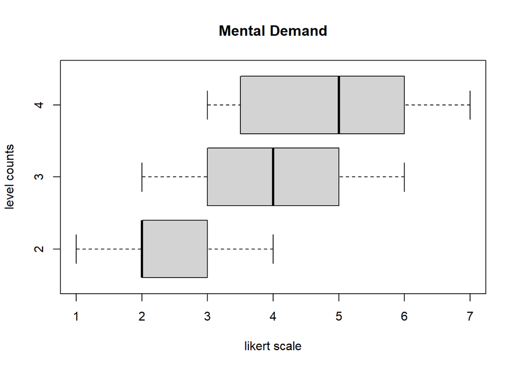

```r
log_MD <- log_tlx_ratings %>%
  filter(Category == "Mental_Demand")

log_MD$ID = factor(log_MD$ID)
log_MD$levelCount = factor(log_MD$levelCount)

boxplot(Score~levelCount,data=log_MD, main="Mental Demand",
   xlab="likert scale", ylab="level counts", horizontal=TRUE, outline = FALSE)
```

```r
MD_summary <- log_MD %>%
  group_by(levelCount) %>%
  summarize(
    meanScore = Score %>% mean(na.rm=TRUE),
    lowCI = ci(Score)[2]%>% pmax(0),
    highCI = ci(Score)[3]%>% pmin(7),
    sd = ci(Score)[4],
    std = Score %>% sd())

MD_summary
```

```
## # A tibble: 3 × 6
##   levelCount meanScore lowCI highCI    sd   std
##   <fct>          <dbl> <dbl>  <dbl> <dbl> <dbl>
## 1 2               2.62  2.15   3.10 0.232  1.13
## 2 3               3.75  3.23   4.27 0.25   1.22
## 3 4               4.96  4.38   5.54 0.279  1.37
```

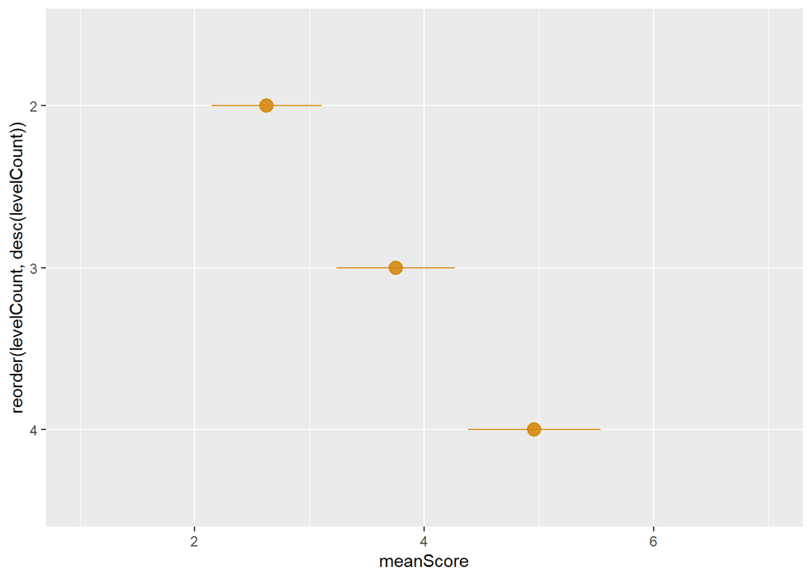

```r
# line + dot
MD_graph <- ggplot(MD_summary) +
  geom_pointrange( aes(x=reorder(levelCount, desc(levelCount)), y=meanScore, ymin=lowCI, ymax=highCI), colour="#d68910", alpha=0.9, size=0.8) +
  scale_y_continuous(lim=c(1,7)) +
  coord_flip()

MD_graph
```

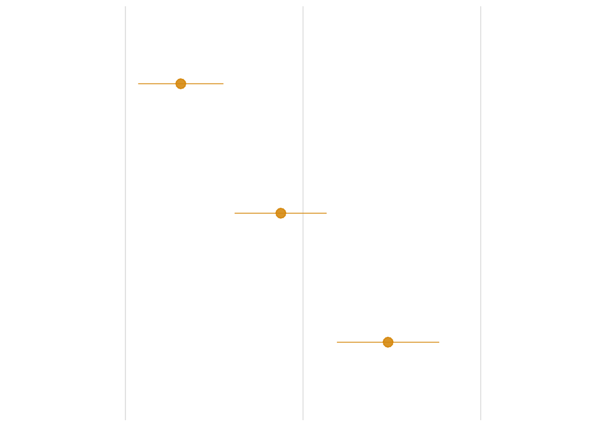

```r
MD_graph + theme( # remove the vertical grid lines
          panel.background = element_blank(),
          panel.grid.major.y = element_blank() ,
          # explicitly set the horizontal lines (or they will disappear too)
          panel.grid.major.x = element_line( size=.1, color="gray" ),
          axis.title.x = element_blank(),
          axis.text.x=element_blank(),
          axis.ticks.x = element_blank(),
          axis.title.y = element_blank(),
          axis.text.y=element_blank(),
          axis.ticks.y = element_blank()
    )
```

```r
ggsave("mental_demand_levels.pdf", width = 3, height = 3)
```

#### analysis

```r
m = aov(Score ~ levelCount, data=log_MD) # make anova-type linear model
shapiro.test(residuals(m))
```

```
##
##  Shapiro-Wilk normality test
##
## data:  residuals(m)
## W = 0.94805, p-value = 0.004914
```

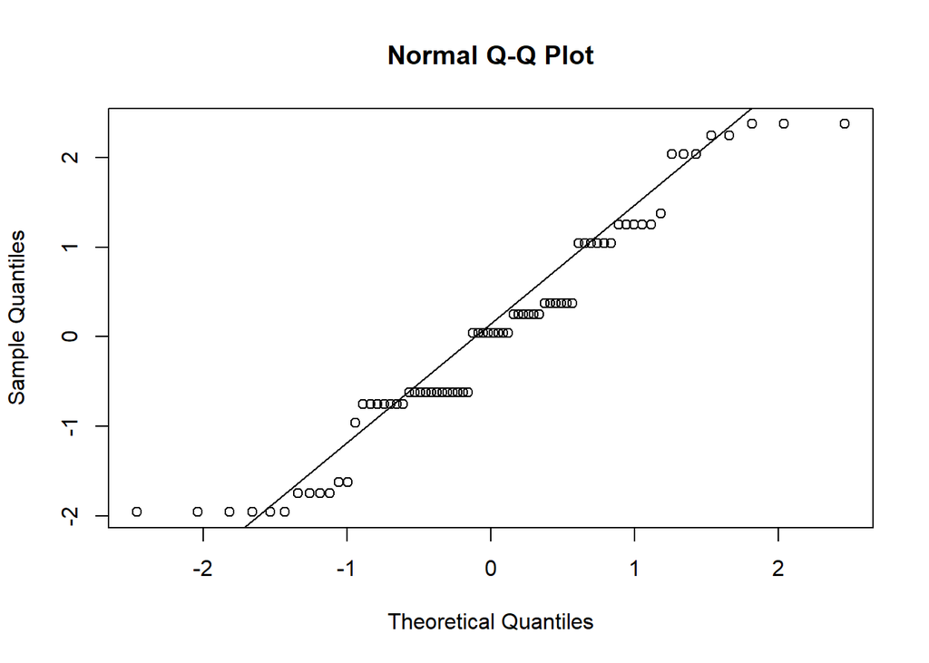

```r
qqnorm(residuals(m)); qqline(residuals(m)) # Q-Q plot
```

```r
# df has subjects (S), one within-Ss factor (X) w/levels (a,b,c), and continuous response (Y)
library(coin)
log_MD$ID = factor(log_MD$ID)
friedman_test(Score ~ levelCount | ID, data=log_MD, distribution="asymptotic")
```

```
##
##  Asymptotic Friedman Test
##
## data:  Score by levelCount (2, 3, 4)
##   stratified by ID
## chi-squared = 36.651, df = 2, p-value = 1.1e-08
```

```r
friedman_effsize(Score ~ levelCount | ID, data=log_MD)
```

```
## # A tibble: 1 × 5
##   .y.       n effsize method    magnitude
## * <chr> <int>   <dbl> <chr>     <ord>
## 1 Score    24   0.764 Kendall W large
```

```r
#
# library(reshape2) # for dcast
# df2 <- dcast(log_MD, ID ~ levelCount, value.var="Score") # make wide-format table
# ab = wilcox.test(df2$"2", df2$"3", paired=TRUE) # a vs. b
# ac = wilcox.test(df2$"2", df2$"4", paired=TRUE) # a vs. c
# bc = wilcox.test(df2$"3", df2$"4", paired=TRUE) # b vs. c
# p.adjust(c(ab$p.value, ac$p.value, bc$p.value), method="holm")

pairwise.wilcox.test(x = log_MD$Score,
                     g = log_MD$levelCount,
                     p.adjust.method = "holm",
                     paired = TRUE)
```

```
##
##  Pairwise comparisons using Wilcoxon signed rank test with continuity correction
##
## data:  log_MD$Score and log_MD$levelCount
##
##   2       3
## 3 0.00052 -
## 4 0.00011 0.00078
##
## P value adjustment method: holm
```

Main effect on levelCounts: 2 is less mental demand than 3 and 4, 3 is less mental demand than 4

#### Physical demand

[figure not shown]

```r
log_PD <- log_tlx_ratings %>%
  filter(Category == "Physical_Demand")

log_PD$ID = factor(log_PD$ID)
log_PD$levelCount = factor(log_PD$levelCount)

boxplot(Score~levelCount,data=log_PD, main="Mental Demand",
   xlab="likert scale", ylab="level counts", horizontal=TRUE, outline = FALSE)
```

```r
PD_summary <- log_PD %>%
  group_by(levelCount) %>%
  summarize(
    meanScore = Score %>% mean(na.rm=TRUE),
    lowCI = ci(Score)[2]%>% pmax(0),
    highCI = ci(Score)[3]%>% pmin(7),
    sd = ci(Score)[4],
    std = Score %>% sd())

PD_summary
```

```
## # A tibble: 3 × 6
##   levelCount meanScore lowCI highCI    sd   std
##   <fct>          <dbl> <dbl>  <dbl> <dbl> <dbl>
## 1 2               2.33  1.87   2.79 0.223  1.09
## 2 3               3.5   2.87   4.13 0.307  1.50
## 3 4               4.08  3.23   4.94 0.412  2.02
```

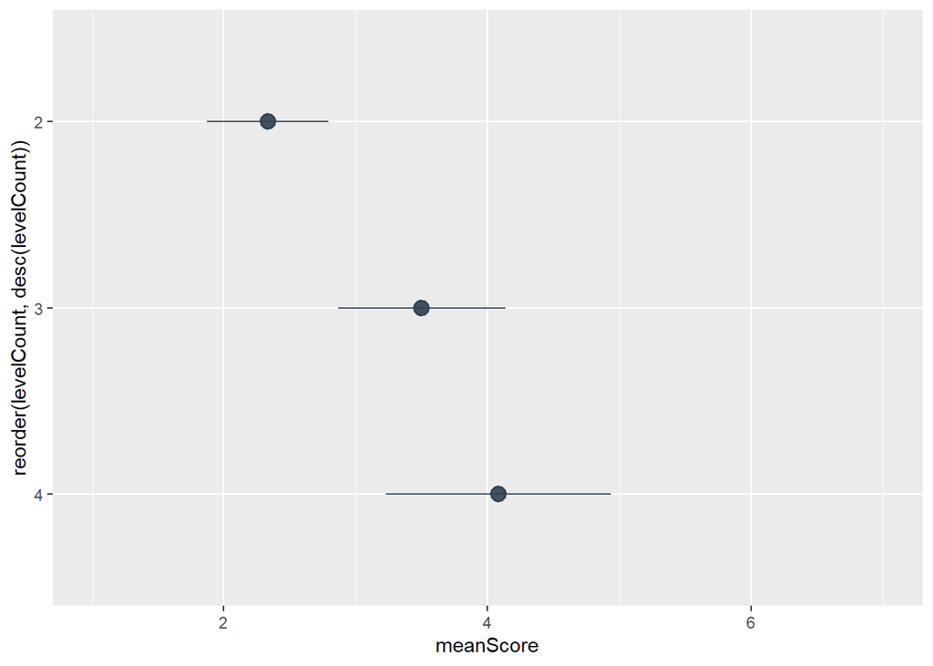

```r
# line + dot
PD_graph <- ggplot(PD_summary) +
  geom_pointrange( aes(x=reorder(levelCount, desc(levelCount)), y=meanScore, ymin=lowCI, ymax=highCI), colour="#2e4053", alpha=0.9, size=0.8) +
  scale_y_continuous(lim=c(1,7)) +
  coord_flip()

PD_graph
```

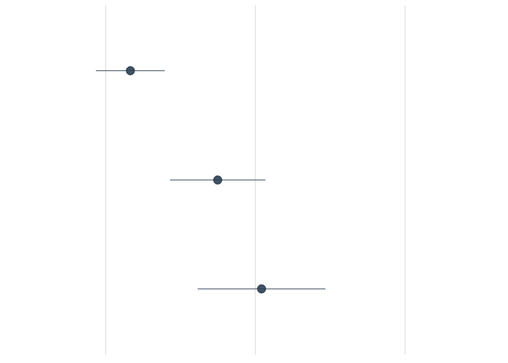

```r
PD_graph + theme( # remove the vertical grid lines
          panel.background = element_blank(),
          panel.grid.major.y = element_blank() ,
          # explicitly set the horizontal lines (or they will disappear too)
          panel.grid.major.x = element_line( size=.1, color="gray" ),
          axis.title.x = element_blank(),
          axis.text.x=element_blank(),
          axis.ticks.x = element_blank(),
          axis.title.y = element_blank(),
          axis.text.y=element_blank(),
          axis.ticks.y = element_blank()
    )
```

```r
ggsave("physical_demand_levels.pdf", width = 3, height = 3)
```

#### analysis

```r
m = aov(Score ~ levelCount, data=log_PD) # make anova-type linear model
shapiro.test(residuals(m))
```

```
##
##  Shapiro-Wilk normality test
##
## data:  residuals(m)
## W = 0.9642, p-value = 0.03828
```

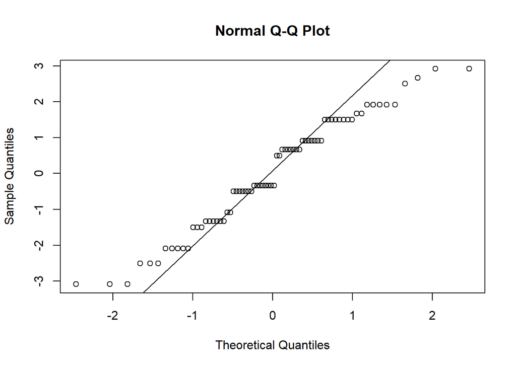

```r
qqnorm(residuals(m)); qqline(residuals(m)) # Q-Q plot
```

```r
# df has subjects (S), one within-Ss factor (X) w/levels (a,b,c), and continuous response (Y)
library(coin)
log_PD$ID = factor(log_PD$ID)
friedman_test(Score ~ levelCount | ID, data=log_PD, distribution="asymptotic")
```

```
##
##  Asymptotic Friedman Test
##
## data:  Score by levelCount (2, 3, 4)
##   stratified by ID
## chi-squared = 22.384, df = 2, p-value = 1.379e-05
```

```r
friedman_effsize(Score ~ levelCount | ID, data=log_PD)
```

```
## # A tibble: 1 × 5
##   .y.       n effsize method    magnitude
## * <chr> <int>   <dbl> <chr>     <ord>
## 1 Score    24   0.466 Kendall W moderate
```

```r
# library(reshape2) # for dcast
# df2 <- dcast(log_PD, ID ~ levelCount, value.var="Score") # make wide-format table
# ab = wilcox.test(df2$"2", df2$"3", paired=TRUE) # a vs. b
# ac = wilcox.test(df2$"2", df2$"4", paired=TRUE) # a vs. c
# bc = wilcox.test(df2$"3", df2$"4", paired=TRUE) # b vs. c
# p.adjust(c(ab$p.value, ac$p.value, bc$p.value), method="holm")

pairwise.wilcox.test(x = log_PD$Score,
                     g = log_PD$levelCount,
                     p.adjust.method = "holm",
                     paired = TRUE)
```

```
##
##  Pairwise comparisons using Wilcoxon signed rank test with continuity correction
##
## data:  log_PD$Score and log_PD$levelCount
##
##   2       3
## 3 0.00072 -
## 4 0.00077 0.03366
##
## P value adjustment method: holm
```

Main effect on levelCounts: 2 is less physical demand than 3 and 4, 3 is less physical demand than 4

#### Temporal demand

[figure not shown]

```r
log_TD <- log_tlx_ratings %>%
  filter(Category == "Temporal_Demand")

log_TD$ID = factor(log_TD$ID)
log_TD$levelCount = factor(log_TD$levelCount)

boxplot(Score~levelCount,data=log_TD, main="Mental Demand",
   xlab="likert scale", ylab="level counts", horizontal=TRUE, outline = FALSE)
```

```r
TD_summary <- log_TD %>%
  group_by(levelCount) %>%
  summarize(
    meanScore = Score %>% mean(na.rm=TRUE),
    lowCI = ci(Score)[2]%>% pmax(0),
    highCI = ci(Score)[3]%>% pmin(7),
    sd = ci(Score)[4],
    std = Score %>% sd())

TD_summary
```

```
## # A tibble: 3 × 6
##   levelCount meanScore lowCI highCI    sd   std
##   <fct>          <dbl> <dbl>  <dbl> <dbl> <dbl>
## 1 2               2.62  2.16   3.09 0.224 1.10
## 2 3               3.17  2.76   3.57 0.197 0.963
## 3 4               3.71  3.25   4.17 0.221 1.08
```

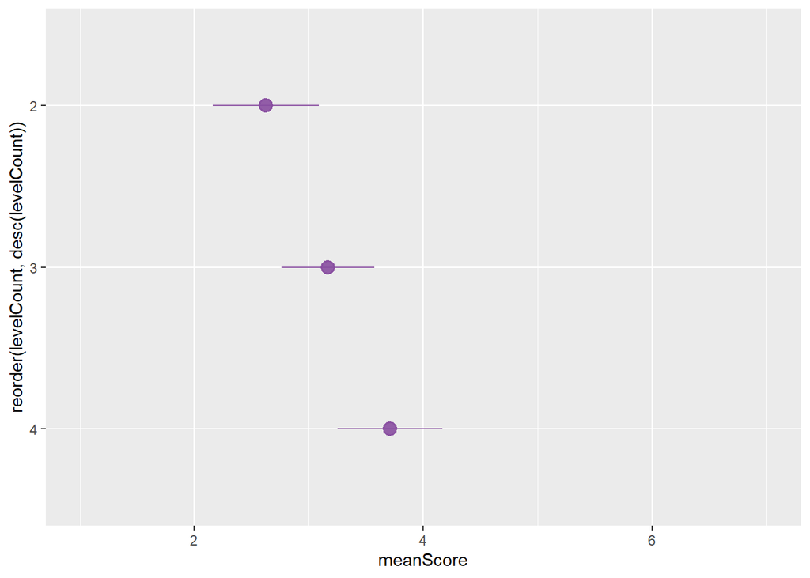

```r
# line + dot
TD_graph <- ggplot(TD_summary) +
  geom_pointrange( aes(x=reorder(levelCount, desc(levelCount)), y=meanScore, ymin=lowCI, ymax=highCI), colour="#884ea0", alpha=0.9, size=0.8) +
  scale_y_continuous(lim=c(1,7)) +
  coord_flip()

TD_graph
```

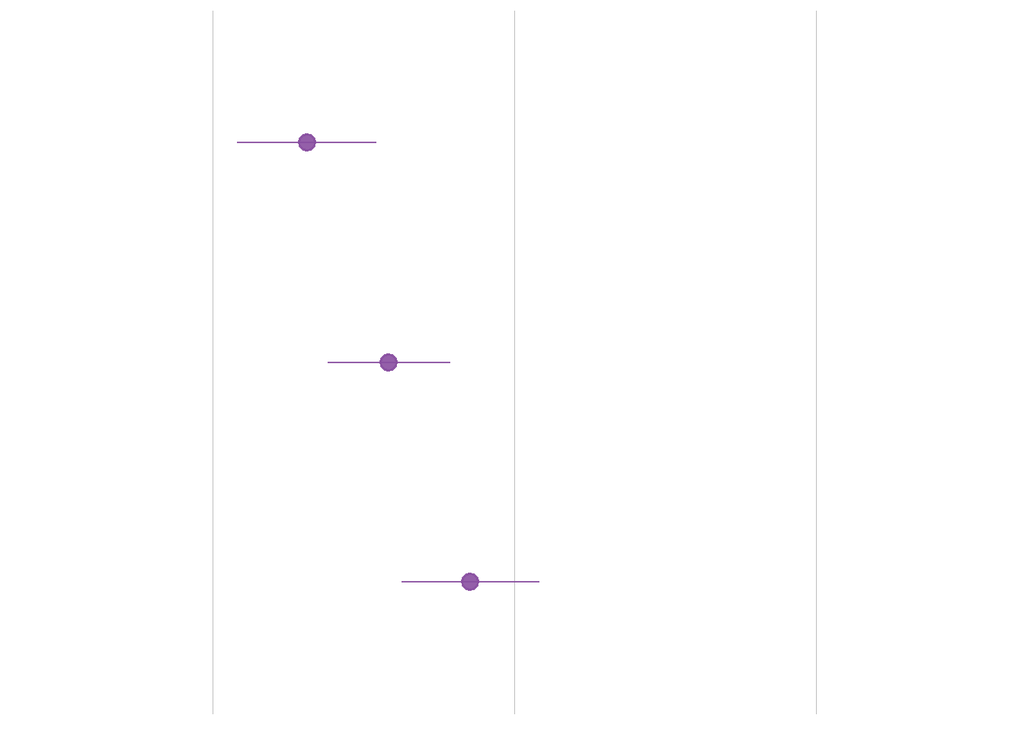

```r
TD_graph + theme( # remove the vertical grid lines
          panel.background = element_blank(),
          panel.grid.major.y = element_blank() ,
          # explicitly set the horizontal lines (or they will disappear too)
          panel.grid.major.x = element_line( size=.1, color="gray" ),
          axis.title.x = element_blank(),
          axis.text.x=element_blank(),
          axis.ticks.x = element_blank(),
          axis.title.y = element_blank(),
          axis.text.y=element_blank(),
          axis.ticks.y = element_blank()
    )
```

```r
ggsave("temporal_demand_levels.pdf", width = 3, height = 3)
```

#### analysis

```r
m = aov(Score ~ levelCount, data=log_TD) # make anova-type linear model
shapiro.test(residuals(m))
```

```
##
##  Shapiro-Wilk normality test
##
## data:  residuals(m)
## W = 0.94754, p-value = 0.004618
```

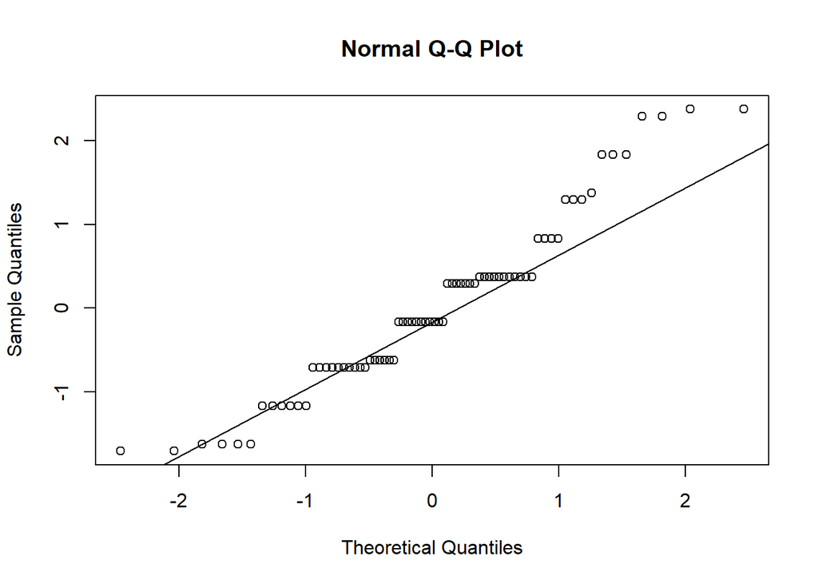

```r
qqnorm(residuals(m)); qqline(residuals(m)) # Q-Q plot
```

```r
# df has subjects (S), one within-Ss factor (X) w/levels (a,b,c), and continuous response (Y)
library(coin)
log_TD$ID = factor(log_TD$ID)
friedman_test(Score ~ levelCount | ID, data=log_TD, distribution="asymptotic")
```

```
##
##  Asymptotic Friedman Test
##
## data:  Score by levelCount (2, 3, 4)
##   stratified by ID
## chi-squared = 22.262, df = 2, p-value = 1.465e-05
```

```r
friedman_effsize(Score ~ levelCount | ID, data=log_TD)
```

```
## # A tibble: 1 × 5
##   .y.       n effsize method    magnitude
## * <chr> <int>   <dbl> <chr>     <ord>
## 1 Score    24   0.464 Kendall W moderate
```

```r
# library(reshape2) # for dcast
# df2 <- dcast(log_TD, ID ~ levelCount, value.var="Score") # make wide-format table
# ab = wilcox.test(df2$"2", df2$"3", paired=TRUE) # a vs. b
# ac = wilcox.test(df2$"2", df2$"4", paired=TRUE) # a vs. c
# bc = wilcox.test(df2$"3", df2$"4", paired=TRUE) # b vs. c
# p.adjust(c(ab$p.value, ac$p.value, bc$p.value), method="holm")

pairwise.wilcox.test(x = log_PD$Score,
                     g = log_PD$levelCount,
                     p.adjust.method = "holm",
                     paired = TRUE)
```

```
##
##  Pairwise comparisons using Wilcoxon signed rank test with continuity correction
##
## data:  log_PD$Score and log_PD$levelCount
##
##   2       3
## 3 0.00072 -
## 4 0.00077 0.03366
##
## P value adjustment method: holm
```

#### Performance

[figure not shown]

```r
log_P <- log_tlx_ratings %>%
  filter(Category == "Performance")

log_P$ID = factor(log_P$ID)
log_P$levelCount = factor(log_P$levelCount)

boxplot(Score~levelCount,data=log_P, main="Mental Demand",
   xlab="likert scale", ylab="level counts", horizontal=TRUE, outline = FALSE)
```

```r
P_summary <- log_P %>%
  group_by(levelCount) %>%
  summarize(
    meanScore = Score %>% mean(na.rm=TRUE),
    lowCI = ci(Score)[2]%>% pmax(0),
    highCI = ci(Score)[3]%>% pmin(7),
    sd = ci(Score)[4],
    std = Score %>% sd())

P_summary
```

```
## # A tibble: 3 × 6
##   levelCount meanScore lowCI highCI    sd   std
##   <fct>          <dbl> <dbl>  <dbl> <dbl> <dbl>
## 1 2               5.42  4.90   5.93 0.248 1.21
## 2 3               4     3.53   4.47 0.225 1.10
## 3 4               3.21  2.80   3.62 0.199 0.977
```

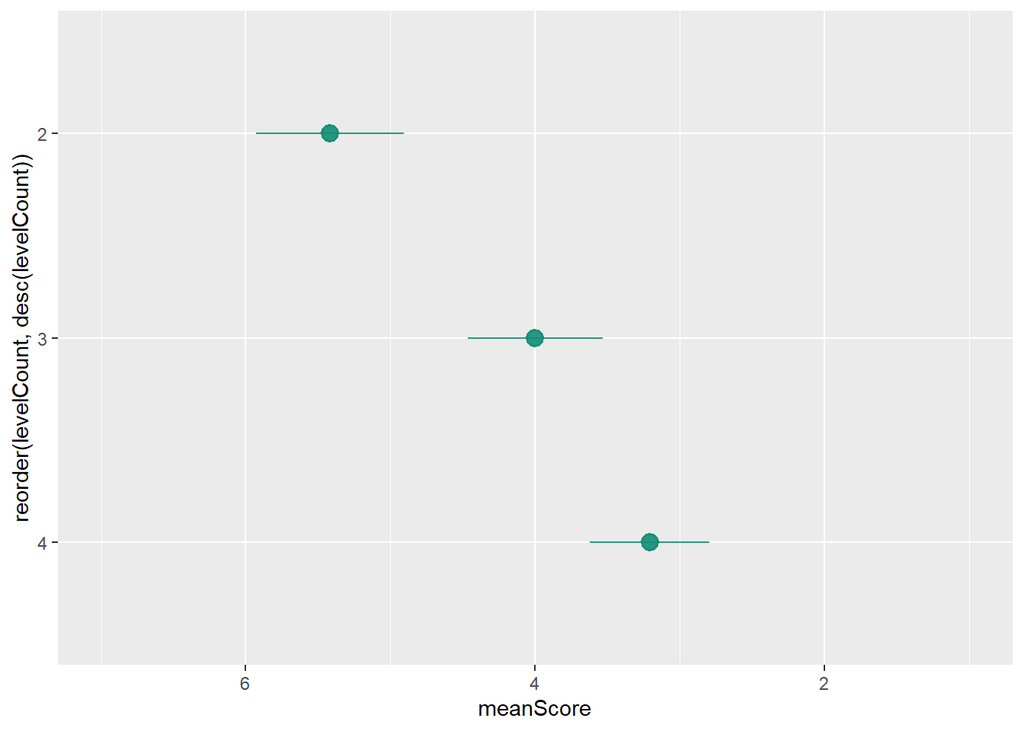

```r
# line + dot
P_graph <- ggplot(P_summary) +
  geom_pointrange( aes(x=reorder(levelCount, desc(levelCount)), y=meanScore, ymin=lowCI, ymax=highCI), colour="#138d75", alpha=0.9, size=0.8) +
  scale_y_reverse(lim=c(7,1)) +
  coord_flip()

P_graph
```

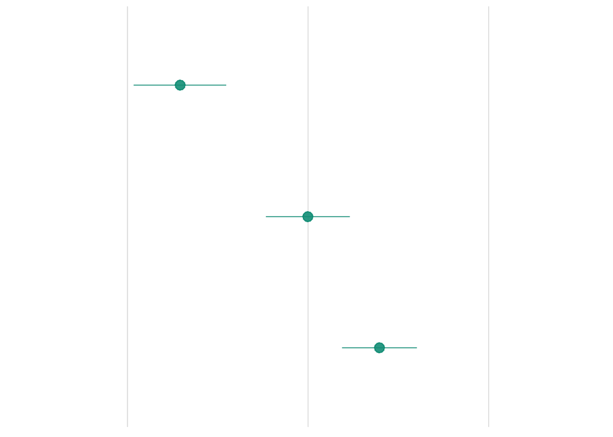

```r
P_graph + theme( # remove the vertical grid lines
          panel.background = element_blank(),
          panel.grid.major.y = element_blank() ,
          # explicitly set the horizontal lines (or they will disappear too)
          panel.grid.major.x = element_line( size=.1, color="gray" ),
          axis.title.x = element_blank(),
          axis.text.x=element_blank(),
          axis.ticks.x = element_blank(),
          axis.title.y = element_blank(),
          axis.text.y=element_blank(),
          axis.ticks.y = element_blank()
    )
```

```r
ggsave("performance_levels.pdf", width = 3, height = 3)
```

#### analysis

```r
m = aov(Score ~ levelCount, data=log_P) # make anova-type linear model
shapiro.test(residuals(m))
```

```
##
##  Shapiro-Wilk normality test
##
## data:  residuals(m)
## W = 0.96388, p-value = 0.03671
```

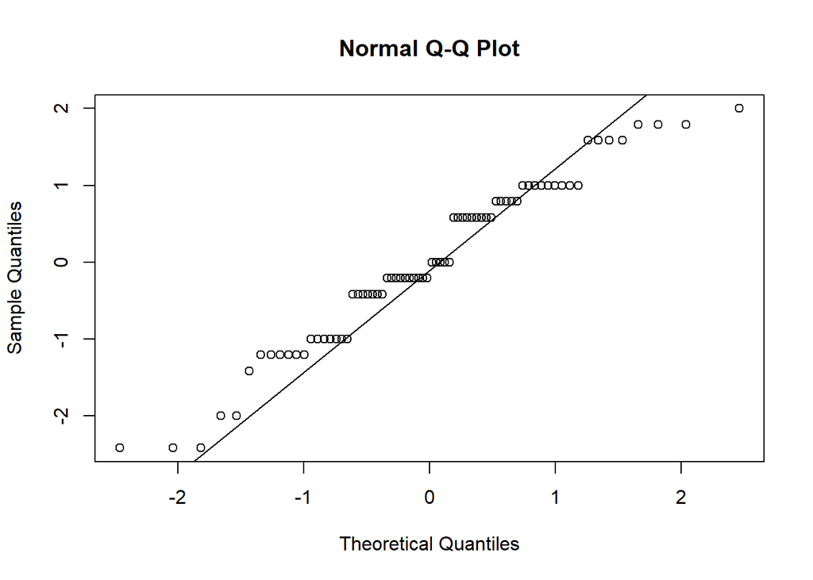

```r
qqnorm(residuals(m)); qqline(residuals(m)) # Q-Q plot
```

```r
# df has subjects (S), one within-Ss factor (X) w/levels (a,b,c), and continuous response (Y)
library(coin)
log_P$ID = factor(log_P$ID)
friedman_test(Score ~ levelCount | ID, data=log_P, distribution="asymptotic")
```

```
##
##  Asymptotic Friedman Test
##
## data:  Score by levelCount (2, 3, 4)
##   stratified by ID
## chi-squared = 27.398, df = 2, p-value = 1.124e-06
```

```r
friedman_effsize(Score ~ levelCount | ID, data=log_P)
```

```
## # A tibble: 1 × 5
##   .y.       n effsize method    magnitude
## * <chr> <int>   <dbl> <chr>     <ord>
## 1 Score    24   0.571 Kendall W large
```

```r
# library(reshape2) # for dcast
# df2 <- dcast(log_P, ID ~ levelCount, value.var="Score") # make wide-format table
# ab = wilcox.test(df2$"2", df2$"3", paired=TRUE) # a vs. b
# ac = wilcox.test(df2$"2", df2$"4", paired=TRUE) # a vs. c
# bc = wilcox.test(df2$"3", df2$"4", paired=TRUE) # b vs. c
# p.adjust(c(ab$p.value, ac$p.value, bc$p.value), method="holm")

pairwise.wilcox.test(x = log_P$Score,
                     g = log_P$levelCount,
                     p.adjust.method = "holm",
                     paired = TRUE)
```

```
##
##  Pairwise comparisons using Wilcoxon signed rank test with continuity correction
##
## data:  log_P$Score and log_P$levelCount
##
##   2       3
## 3 0.00268 -
## 4 0.00022 0.02180
##
## P value adjustment method: holm
```

Main effect on levelCounts: 2 is better than 3 and 4, 3 is better than 4

#### Effort

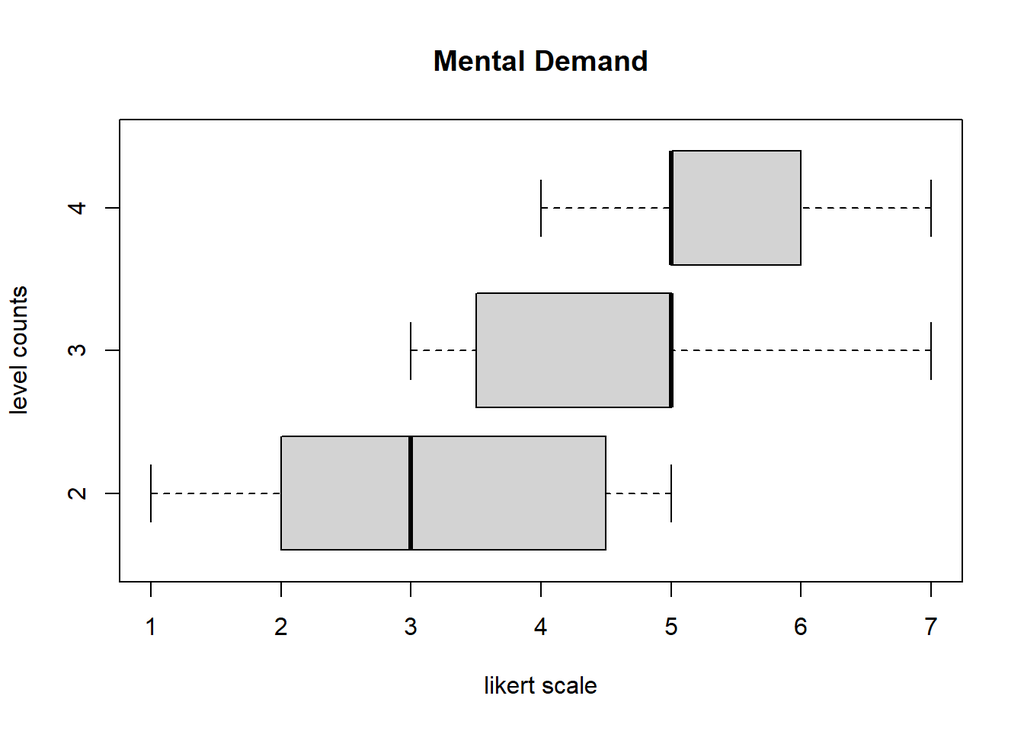

```r
log_E <- log_tlx_ratings %>%
  filter(Category == "Effort")

log_E$ID = factor(log_E$ID)
log_E$levelCount = factor(log_E$levelCount)

boxplot(Score~levelCount,data=log_E, main="Mental Demand",
   xlab="likert scale", ylab="level counts", horizontal=TRUE, outline = FALSE)
```

```r
E_summary <- log_E %>%
  group_by(levelCount) %>%
  summarize(
    meanScore = Score %>% mean(na.rm=TRUE),
    lowCI = ci(Score)[2]%>% pmax(0),
    highCI = ci(Score)[3]%>% pmin(7),
    sd = ci(Score)[4],
    std = Score %>% sd())

E_summary
```

```
## # A tibble: 3 × 6
##   levelCount meanScore lowCI highCI    sd   std
##   <fct>          <dbl> <dbl>  <dbl> <dbl> <dbl>
## 1 2               3.12  2.55   3.70 0.278 1.36
## 2 3               4.42  3.97   4.86 0.216 1.06
## 3 4               5.33  4.97   5.70 0.177 0.868
```

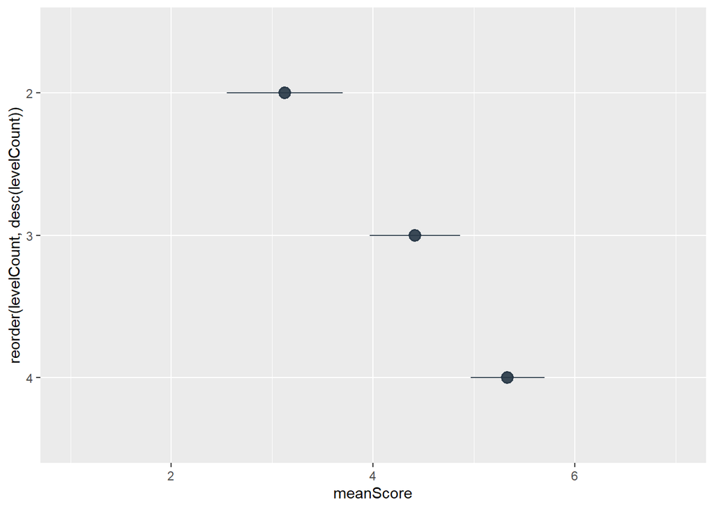

```r
# line + dot
E_graph <- ggplot(E_summary) +
  geom_pointrange( aes(x=reorder(levelCount, desc(levelCount)), y=meanScore, ymin=lowCI, ymax=highCI), colour="#273746", alpha=0.9, size=0.8) +
  scale_y_continuous(lim=c(1,7)) +
  coord_flip()

E_graph
```

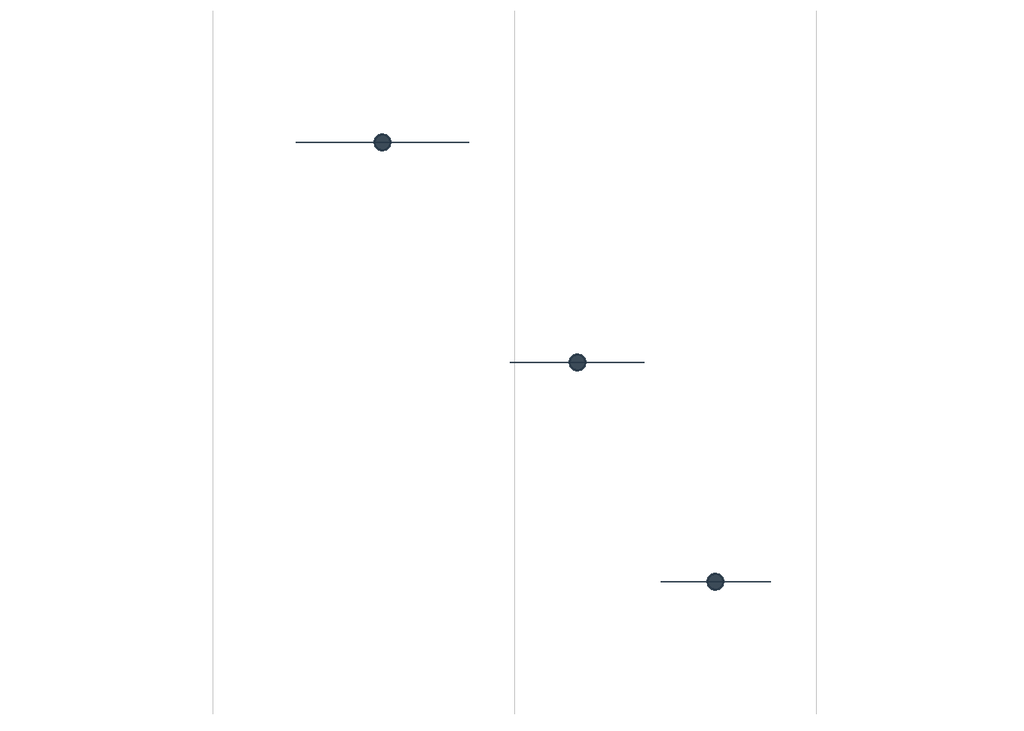

```r
E_graph + theme( # remove the vertical grid lines
          panel.background = element_blank(),
          panel.grid.major.y = element_blank() ,
          # explicitly set the horizontal lines (or they will disappear too)
          panel.grid.major.x = element_line( size=.1, color="gray" ),
          axis.title.x = element_blank(),
          axis.text.x=element_blank(),
          axis.ticks.x = element_blank(),
          axis.title.y = element_blank(),
          axis.text.y=element_blank(),
          axis.ticks.y = element_blank()
    )
```

```r
ggsave("effort_levels.pdf", width = 3, height = 3)
```

#### analysis

```r
m = aov(Score ~ levelCount, data=log_E) # make anova-type linear model
shapiro.test(residuals(m))
```

```
##
##  Shapiro-Wilk normality test
##
## data:  residuals(m)
## W = 0.9588, p-value = 0.01891
```

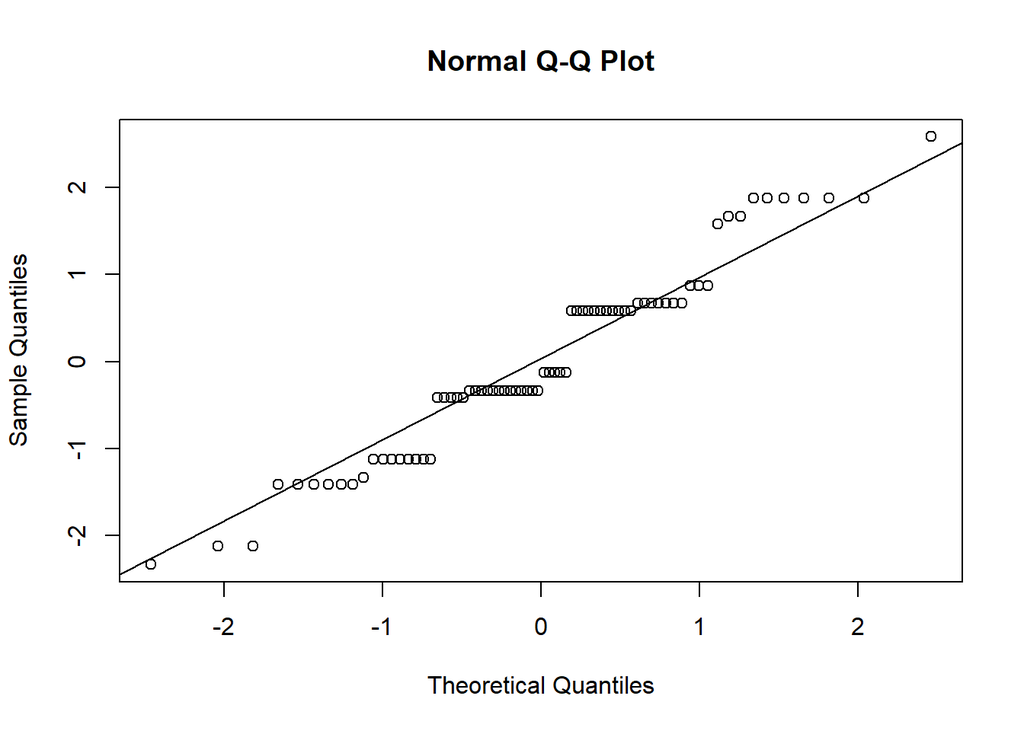

```r
qqnorm(residuals(m)); qqline(residuals(m)) # Q-Q plot
```

```r
# df has subjects (S), one within-Ss factor (X) w/levels (a,b,c), and continuous response (Y)
library(coin)
log_E$ID = factor(log_E$ID)
friedman_test(Score ~ levelCount | ID, data=log_E, distribution="asymptotic")
```

```
##
##  Asymptotic Friedman Test
##
## data:  Score by levelCount (2, 3, 4)
##   stratified by ID
## chi-squared = 35.175, df = 2, p-value = 2.301e-08
```

```r
friedman_effsize(Score ~ levelCount | ID, data=log_E)
```

```
## # A tibble: 1 × 5
##   .y.       n effsize method    magnitude
## * <chr> <int>   <dbl> <chr>     <ord>
## 1 Score    24   0.733 Kendall W large
```

```r
# library(reshape2) # for dcast
# df2 <- dcast(log_E, ID ~ levelCount, value.var="Score") # make wide-format table
# ab = wilcox.test(df2$"2", df2$"3", paired=TRUE) # a vs. b
# ac = wilcox.test(df2$"2", df2$"4", paired=TRUE) # a vs. c
# bc = wilcox.test(df2$"3", df2$"4", paired=TRUE) # b vs. c
# p.adjust(c(ab$p.value, ac$p.value, bc$p.value), method="holm")

pairwise.wilcox.test(x = log_E$Score,
                     g = log_E$levelCount,
                     p.adjust.method = "holm",
                     paired = TRUE)
```

```
##
##  Pairwise comparisons using Wilcoxon signed rank test with continuity correction
##
## data:  log_E$Score and log_E$levelCount
##
##   2       3
## 3 0.00046 -
## 4 0.00016 0.00046
##
## P value adjustment method: holm
```

Main effect on levelCounts: 2 is less effort than 3 and 4, 3 is less effort than 4

#### Frustration

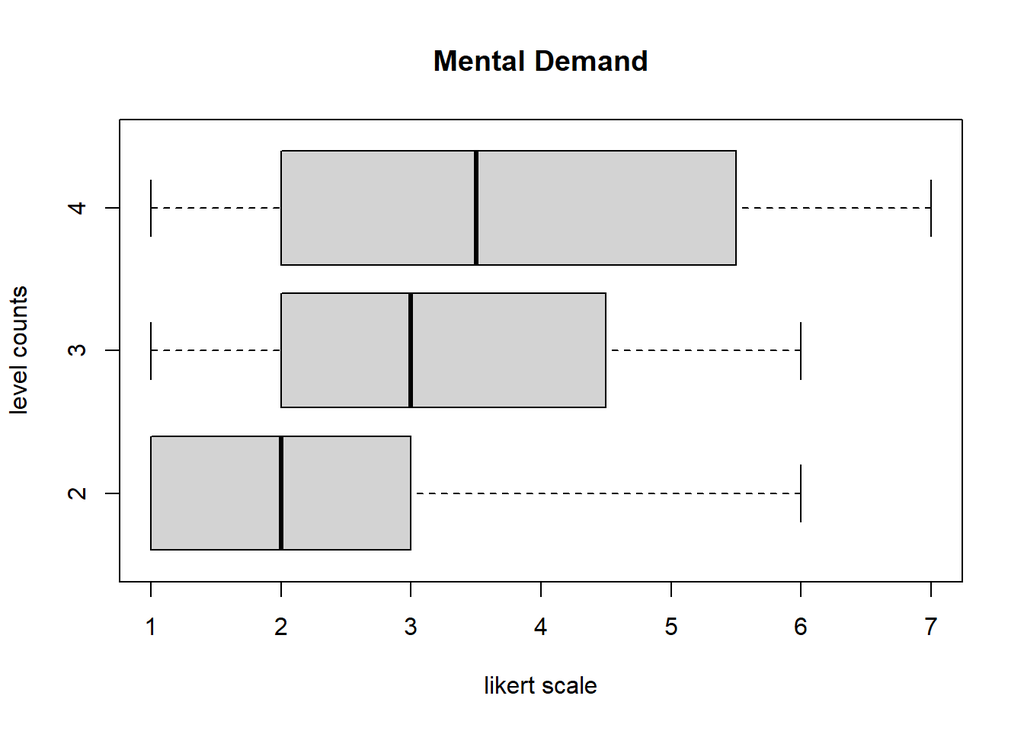

```r
log_F <- log_tlx_ratings %>%
  filter(Category == "Frustration")

log_F$ID = factor(log_F$ID)
log_F$levelCount = factor(log_F$levelCount)

boxplot(Score~levelCount,data=log_F, main="Mental Demand",
   xlab="likert scale", ylab="level counts", horizontal=TRUE, outline = FALSE)
```

```r
F_summary <- log_F %>%
  group_by(levelCount) %>%
  summarize(
    meanScore = Score %>% mean(na.rm=TRUE),
    lowCI = ci(Score)[2]%>% pmax(0),
    highCI = ci(Score)[3]%>% pmin(7),
    sd = ci(Score)[4],
    std = Score %>% sd())

F_summary
```

```
## # A tibble: 3 × 6
##   levelCount meanScore lowCI highCI    sd   std
##   <fct>          <dbl> <dbl>  <dbl> <dbl> <dbl>
## 1 2               2.33  1.70   2.96 0.305  1.49
## 2 3               3.12  2.43   3.82 0.337  1.65
## 3 4               3.79  2.94   4.65 0.413  2.02
```

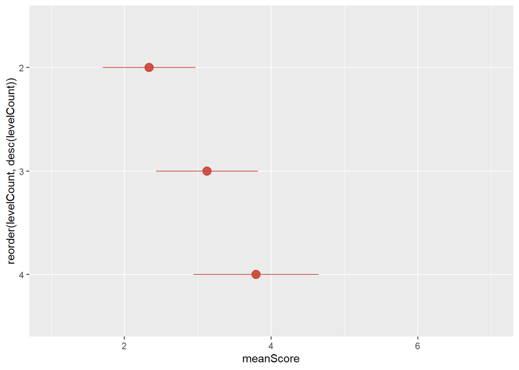

```r
# line + dot
F_graph <- ggplot(F_summary) +
  geom_pointrange( aes(x=reorder(levelCount, desc(levelCount)), y=meanScore, ymin=lowCI, ymax=highCI), colour="#cb4335", alpha=0.9, size=0.8) +
  scale_y_continuous(lim=c(1,7)) +
  coord_flip()

F_graph
```

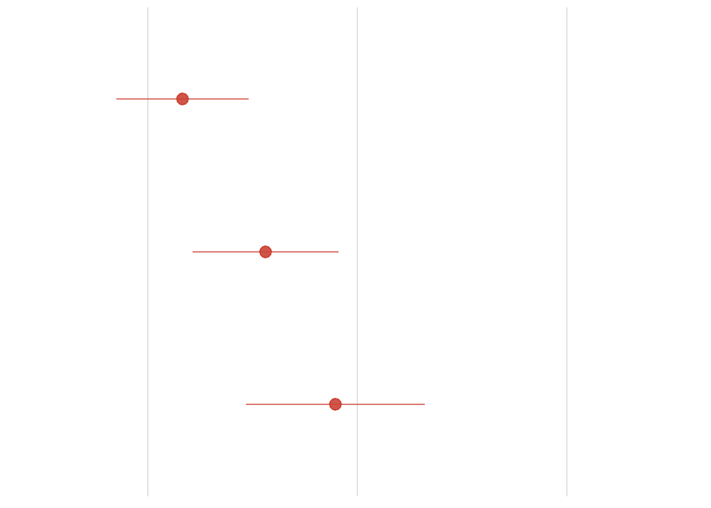

```r
F_graph + theme( # remove the vertical grid lines
          panel.background = element_blank(),
          panel.grid.major.y = element_blank() ,
          # explicitly set the horizontal lines (or they will disappear too)
          panel.grid.major.x = element_line( size=.1, color="gray" ),
          axis.title.x = element_blank(),
          axis.text.x=element_blank(),
          axis.ticks.x = element_blank(),
          axis.title.y = element_blank(),
          axis.text.y=element_blank(),
          axis.ticks.y = element_blank()
    )
```

```r
ggsave("frustration_levels.pdf", width = 3, height = 3)
```

#### analysis

```r
m = aov(Score ~ levelCount, data=log_F) # make anova-type linear model
shapiro.test(residuals(m))
```

```
##
##  Shapiro-Wilk normality test
##
## data:  residuals(m)
## W = 0.95118, p-value = 0.007218
```

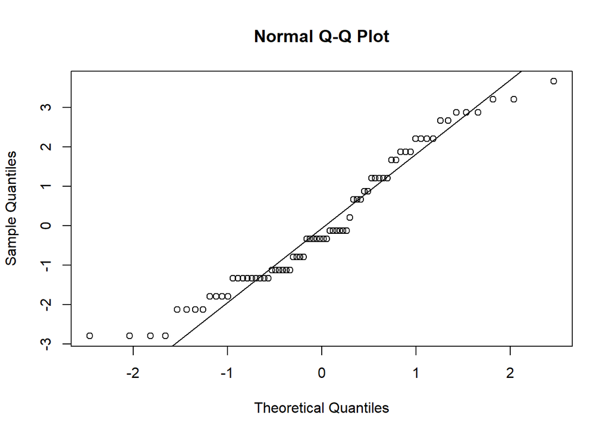

```r
qqnorm(residuals(m)); qqline(residuals(m)) # Q-Q plot
```

```r
# df has subjects (S), one within-Ss factor (X) w/levels (a,b,c), and continuous response (Y)
library(coin)
log_F$ID = factor(log_F$ID)
friedman_test(Score ~ levelCount | ID, data=log_F, distribution="asymptotic")
```

```
##
##  Asymptotic Friedman Test
##
## data:  Score by levelCount (2, 3, 4)
##   stratified by ID
## chi-squared = 19.6, df = 2, p-value = 5.545e-05
```

```r
friedman_effsize(Score ~ levelCount | ID, data=log_F)
```

```
## # A tibble: 1 × 5
##   .y.       n effsize method    magnitude
## * <chr> <int>   <dbl> <chr>     <ord>
## 1 Score    24   0.408 Kendall W moderate
```

```r
# library(reshape2) # for dcast
# df2 <- dcast(log_F, ID ~ levelCount, value.var="Score") # make wide-format table
# ab = wilcox.test(df2$"2", df2$"3", paired=TRUE) # a vs. b
# ac = wilcox.test(df2$"2", df2$"4", paired=TRUE) # a vs. c
# bc = wilcox.test(df2$"3", df2$"4", paired=TRUE) # b vs. c
# p.adjust(c(ab$p.value, ac$p.value, bc$p.value), method="holm")

pairwise.wilcox.test(x = log_F$Score,
                     g = log_F$levelCount,
                     p.adjust.method = "holm",
                     paired = TRUE)
```

```
##
##  Pairwise comparisons using Wilcoxon signed rank test with continuity correction
##
## data:  log_F$Score and log_F$levelCount
##
##   2      3
## 3 0.0214 -
## 4 0.0013 0.0509
##
## P value adjustment method: holm
```

Main effect on levelCounts: 2 is less frustration than 3 and 4

#### Learnability

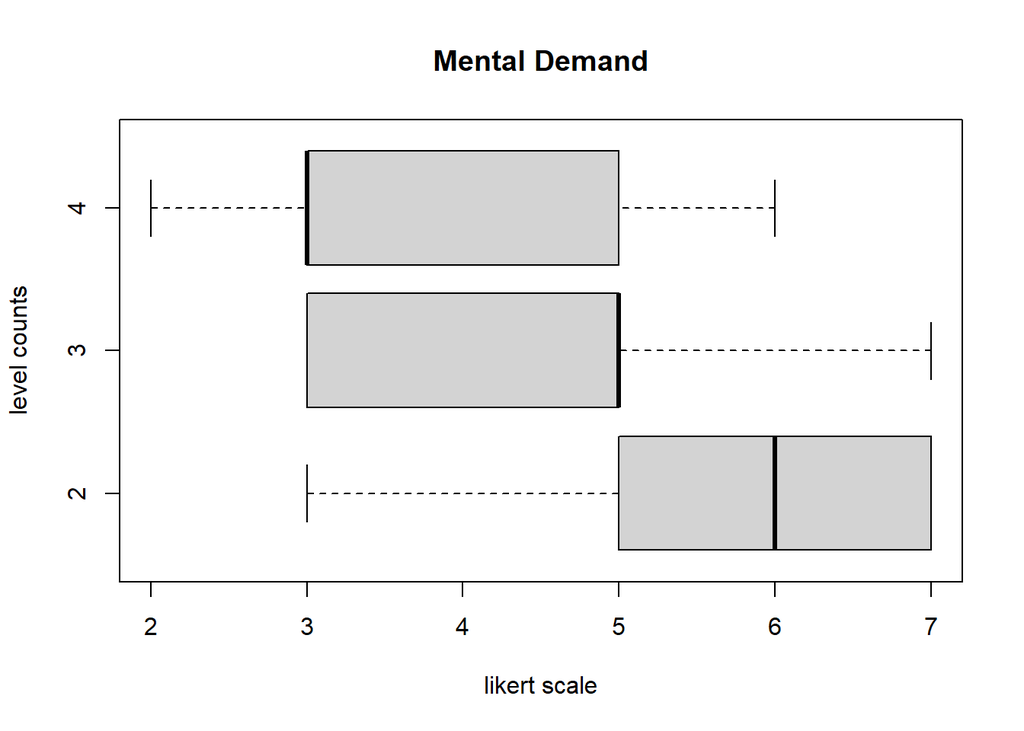

```r
log_L <- log_tlx_ratings %>%
  filter(Category == "Learnability")

log_L$ID = factor(log_L$ID)
log_L$levelCount = factor(log_L$levelCount)

boxplot(Score~levelCount,data=log_L, main="Mental Demand",
   xlab="likert scale", ylab="level counts", horizontal=TRUE, outline = FALSE)
```

```r
L_summary <- log_L %>%
  group_by(levelCount) %>%
  summarize(
    meanScore = Score %>% mean(na.rm=TRUE),
    lowCI = ci(Score)[2]%>% pmax(0),
    highCI = ci(Score)[3]%>% pmin(7),
    sd = ci(Score)[4],
    std = Score %>% sd())

L_summary
```

```
## # A tibble: 3 × 6
##   levelCount meanScore lowCI highCI    sd   std
##   <fct>          <dbl> <dbl>  <dbl> <dbl> <dbl>
## 1 2               5.88  5.40   6.35 0.228  1.12
## 2 3               4.54  4.03   5.05 0.248  1.22
## 3 4               3.5   2.96   4.04 0.262  1.29
```

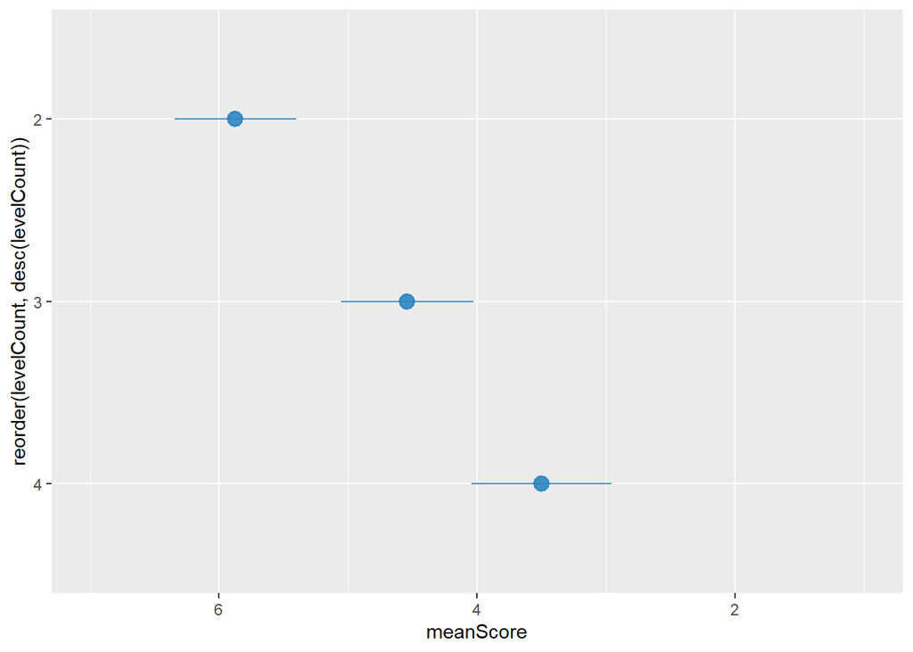

```r
# line + dot
L_graph <- ggplot(L_summary) +
  geom_pointrange( aes(x=reorder(levelCount, desc(levelCount)), y=meanScore, ymin=lowCI, ymax=highCI), colour="#2e86c1", alpha=0.9, size=0.8) +
  scale_y_reverse(lim=c(7,1)) +
  coord_flip()

L_graph
```

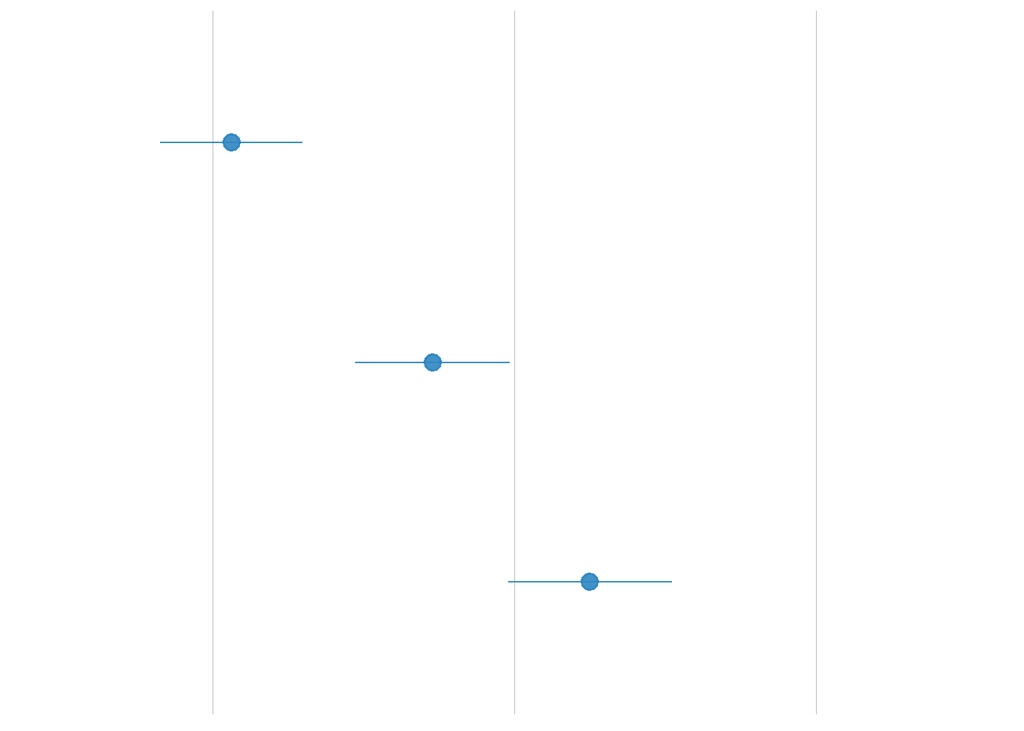

```r
L_graph + theme( # remove the vertical grid lines
          panel.background = element_blank(),
          panel.grid.major.y = element_blank() ,
          # explicitly set the horizontal lines (or they will disappear too)
          panel.grid.major.x = element_line( size=.1, color="gray" ),
          axis.title.x = element_blank(),
          axis.text.x=element_blank(),
          axis.ticks.x = element_blank(),
          axis.title.y = element_blank(),
          axis.text.y=element_blank(),
          axis.ticks.y = element_blank()
    )
```

```r
ggsave("learnability_levels.pdf", width = 3, height = 3)
```

#### analysis

```r
m = aov(Score ~ levelCount, data=log_L) # make anova-type linear model
shapiro.test(residuals(m))
```

```
##
##  Shapiro-Wilk normality test
##
## data:  residuals(m)
## W = 0.96299, p-value = 0.03264
```

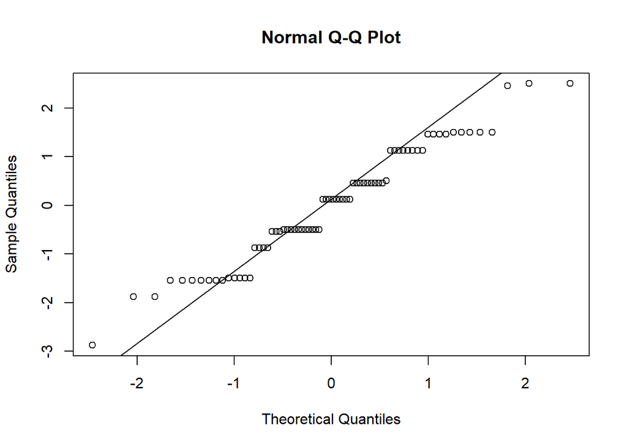

```r
qqnorm(residuals(m)); qqline(residuals(m)) # Q-Q plot
```

```r
# df has subjects (S), one within-Ss factor (X) w/levels (a,b,c), and continuous response (Y)
library(coin)
log_L$ID = factor(log_L$ID)
friedman_test(Score ~ levelCount | ID, data=log_L, distribution="asymptotic")
```

```
##
##  Asymptotic Friedman Test
##
## data:  Score by levelCount (2, 3, 4)
##   stratified by ID
## chi-squared = 39.687, df = 2, p-value = 2.411e-09
```

```r
friedman_effsize(Score ~ levelCount | ID, data=log_F)
```

```
## # A tibble: 1 × 5
##   .y.       n effsize method    magnitude
## * <chr> <int>   <dbl> <chr>     <ord>
## 1 Score    24   0.408 Kendall W moderate
```

```r
#
# library(reshape2) # for dcast
# df2 <- dcast(log_L, ID ~ levelCount, value.var="Score") # make wide-format table
# ab = wilcox.test(df2$"2", df2$"3", paired=TRUE) # a vs. b
# ac = wilcox.test(df2$"2", df2$"4", paired=TRUE) # a vs. c
# bc = wilcox.test(df2$"3", df2$"4", paired=TRUE) # b vs. c
# p.adjust(c(ab$p.value, ac$p.value, bc$p.value), method="holm")

pairwise.wilcox.test(x = log_L$Score,
                     g = log_L$levelCount,
                     p.adjust.method = "holm",
                     paired = TRUE)
```

```
##
##  Pairwise comparisons using Wilcoxon signed rank test with continuity correction
##
## data:  log_L$Score and log_L$levelCount
##
##   2       3
## 3 0.00021 -
## 4 7.2e-05 0.00238
##
## P value adjustment method: holm
```

Main effect on levelCounts: 2 is easier to learn than 3 and 4, 3 is easier to learn than 4

#### 2 level - easiness

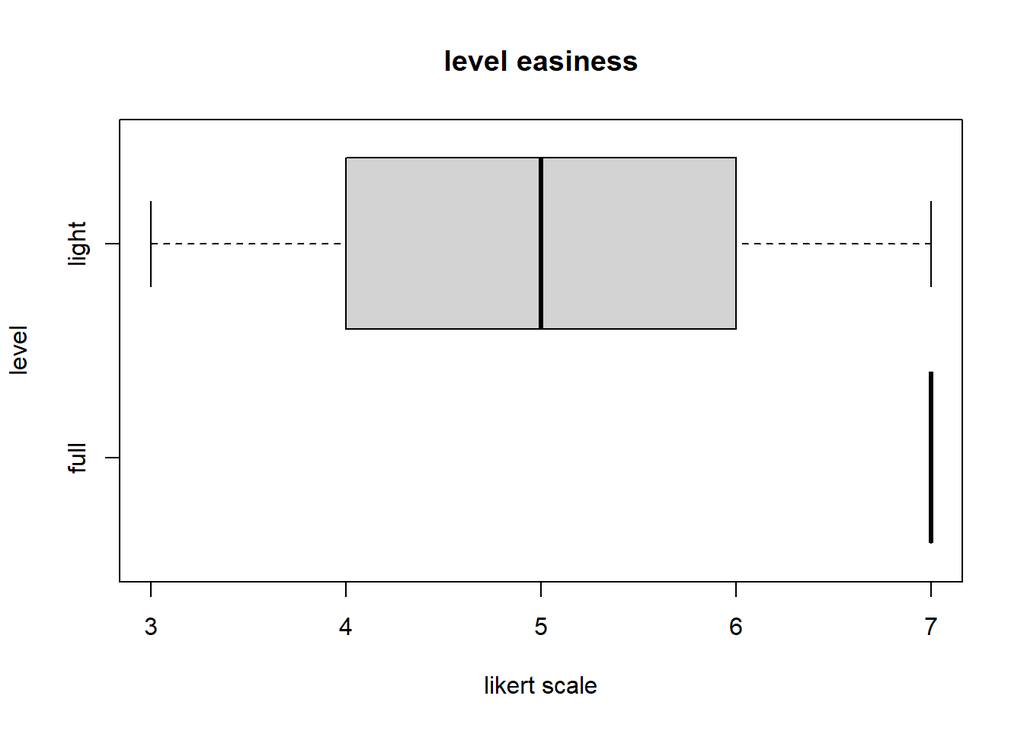

```r
level2_data_level <- level2_data %>%
  dplyr::select(ID, Light_easiness:Full_easiness)

colnames(level2_data_level) <- c("ID", "light", "full")

level2_data_level_long <- level2_data_level %>%
  pivot_longer(
    cols = light:full, # Selects columns that start with "Test"
    names_to = "Level",     # Name for the new column holding the original column names (e.g., Test1)
    values_to = "Score"        # Name for the new column holding the values (e.g., 85, 92)
  )

level2_data_key <- level2_data %>%
  dplyr::select(ID, A_easiness:Semicolon_easiness)

colnames(level2_data_key) <- c("ID", "A", "S", "D", "F", "J", "K", "L", "Semicolon")

level2_data_key_long <- level2_data_key %>%
  pivot_longer(
    cols = A:Semicolon, # Selects columns that start with "Test"
    names_to = "Key",     # Name for the new column holding the original column names (e.g., Test1)
    values_to = "Score"        # Name for the new column holding the values (e.g., 85, 92)
  )

level2_data_level_long$ID = factor(level2_data_level_long$ID)
level2_data_level_long$Level = factor(level2_data_level_long$Level, two_level_code)

boxplot(Score~Level,data=level2_data_level_long, main="level easiness",
   xlab="likert scale", ylab="level", horizontal=TRUE, outline = FALSE)
```

```r
level2_data_level_summary <- level2_data_level_long %>%
  group_by(Level) %>%
  summarize(
    meanScore = Score %>% mean(na.rm=TRUE),
    lowCI = ci(Score)[2]%>% pmax(0),
    highCI = ci(Score)[3]%>% pmin(7),
    sd = ci(Score)[4],
    std = Score %>% sd())

level2_data_level_summary
```

```
## # A tibble: 2 × 6
##   Level meanScore lowCI highCI     sd   std
##   <fct>     <dbl> <dbl>  <dbl>  <dbl> <dbl>
## 1 full       6.92  6.80   7    0.0576 0.282
## 2 light      5.12  4.64   5.61 0.236  1.15
```

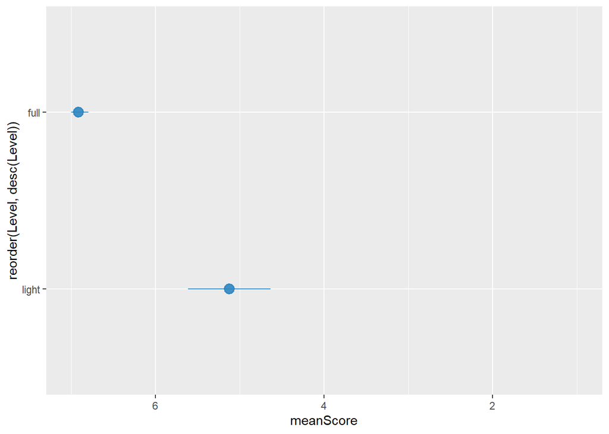

```r
# line + dot
level2_data_level_graph <- ggplot(level2_data_level_summary) +
  geom_pointrange( aes(x=reorder(Level, desc(Level)), y=meanScore, ymin=lowCI, ymax=highCI), colour="#2e86c1", alpha=0.9, size=0.8) +
  scale_y_reverse(lim=c(7,1)) +
  coord_flip()

level2_data_level_graph
```

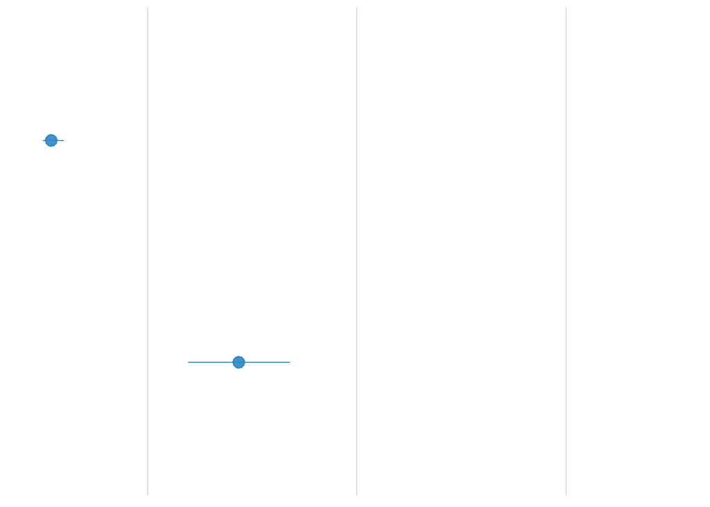

```r
level2_data_level_graph + theme( # remove the vertical grid lines
          panel.background = element_blank(),
          panel.grid.major.y = element_blank() ,
          # explicitly set the horizontal lines (or they will disappear too)
          panel.grid.major.x = element_line( size=.1, color="gray" ),
          axis.title.x = element_blank(),
          axis.text.x=element_blank(),
          axis.ticks.x = element_blank(),
          axis.title.y = element_blank(),
          axis.text.y=element_blank(),
          axis.ticks.y = element_blank()
    )
```